# MSA Type 2 Study

Hae-Joong

2017년 4월 25일

## Type 2 study(Gage R&R 연구)

전체 측정시스템에 대한 측정능력을 평가하는 절차 측정작업자가 포함된 경우의 분석을 Type 2 Study 포함되지 않은 경우의 분석을 Type 3 Study.

측정의 총변동량 = 공정의 변동량 + **측정시스템의 변동량(계측기와 측정작업자의 변동량)**

측정시스템의 변동량 = 반복성 + 재현성

반복성(계측기변동) : 동일의 측정작업자가 동일의 계측기를 갖는 동일한 부품을 측정하였을 때 파생되는 측정의 변동

재현성 : 동일한 계측기로 동일한 부품을 측정하였을 때에 측정자 간에 나타나는 측정치의 변동

### 1.분산분석 방법에 의한 Gage R&R 분석 절차

패키지 : Sixsigma

함수 : ss.rr()

Gage R & R (Measurement System Assessment)

**Description**

Performs Gage R&R analysis for the assessment of the measurement system of a process. Related to the Measure phase of the DMAIC strategy of Six Sigma.

**Usage**

ss.rr(var, part, appr, lsl = NA, usl = NA, sigma = 6, data, main = “Six Sigma Gage R&R Study”, sub = “”, alphaLim = 0.05, errorTerm = “interaction”, digits = 4)

**Arguments**

var : Measured variable

part : Factor for parts

appr : Factor for appraisers (operators, machines, …)

lsl : Numeric value of lower specification limit used with USL to calculate Study Variation as %Tolerance

usl : Numeric value of upper specification limit used with LSL to calculate Study Variation as %Tolerance

sigma : Numeric value for number of std deviations to use in calculating Study Variation

data : Data frame containing the variables

main :Main title for the graphic output

sub : Subtitle for the graphic output (recommended the name of the project)

alphaLim : Limit to take into account interaction

errorTerm : Which term of the model should be used as error term (for the model with interation)

digits : Number of decimal digits for output

**Details**

Performs an R&R study for the measured variable, taking into account part and appraiser factors. It outputs the sources of Variability, and six graphs: bar chart with the sources of Variability, plots by appraiser, part and interaction and x-bar and R control charts.

**value**

Analysis of Variance Table/s. Variance composition and %Study Var. Graphics.

anovaTable : The ANOVA table of the model anovaRed : The ANOVA table of the reduced model (without interaction, only if interaction not significant)

varComp : A matrix with the contribution of each component to the total variation

studyVar : A matrix with the contribution to the study variation

ncat : Number of distinct categories

ss.rr() #함수를 기본 예제로 수행함

```r
library(SixSigma)
ss.rr(time1, prototype, operator, data = ss.data.rr,
    sub = "Six Sigma Paper Helicopter Project",
    alphaLim = 0.05,
    errorTerm = "interaction",
    lsl = 0.7,
    usl = 1.8)
```

```
## Complete model (with interaction):
##
##                    Df Sum Sq Mean Sq F value  Pr(>F)
## prototype           2 1.2007  0.6004  28.797 0.00422
## operator            2 0.0529  0.0265   1.270 0.37415
## prototype:operator  4 0.0834  0.0208   0.974 0.44619
## Repeatability      18 0.3854  0.0214
## Total              26 1.7225
##
## alpha for removing interaction: 0.05
##
##
## Reduced model (without interaction):
##
##               Df Sum Sq Mean Sq F value   Pr(>F)
## prototype      2 1.2007  0.6004  28.174 8.56e-07
## operator       2 0.0529  0.0265   1.242    0.308
## Repeatability 22 0.4688  0.0213
## Total         26 1.7225
##
## Gage R&R
##
##                        VarComp %Contrib
## Total Gage R&R    0.0218822671    25.38
##   Repeatability   0.0213087542    24.71
##   Reproducibility 0.0005735129     0.67
##     operator      0.0005735129     0.67
## Part-To-Part      0.0643389450    74.62
## Total Variation   0.0862212121   100.00
##
##                        VarComp     StdDev  StudyVar %StudyVar %Tolerance
## Total Gage R&R    0.0218822671 0.14792656 0.8875594     50.38      80.69
##   Repeatability   0.0213087542 0.14597518 0.8758511     49.71      79.62
##   Reproducibility 0.0005735129 0.02394813 0.1436888      8.16      13.06
##     operator      0.0005735129 0.02394813 0.1436888      8.16      13.06
## Part-To-Part      0.0643389450 0.25365123 1.5219074     86.38     138.36
## Total Variation   0.0862212121 0.29363449 1.7618069    100.00     160.16
##
## Number of Distinct Categories = 2
```

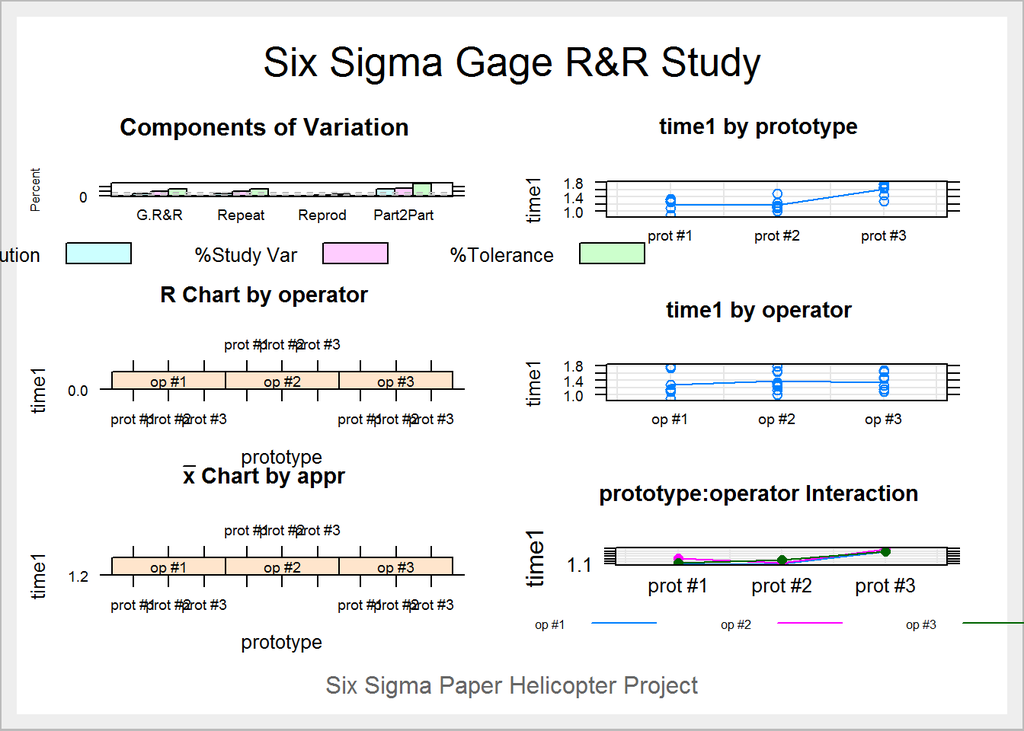

```r
str(ss.data.rr)
```

```
## 'data.frame':    27 obs. of  5 variables:
##  $ prototype: Factor w/ 3 levels "prot #1","prot #2",..: 1 1 1 2 2 2 3 3 3 1 ...
##  $ operator : Factor w/ 3 levels "op #1","op #2",..: 1 1 1 1 1 1 1 1 1 2 ...
##  $ run      : Factor w/ 3 levels "run #1","run #2",..: 1 2 3 1 2 3 1 2 3 1 ...
##  $ time1    : num  1.27 0.9 1.09 1.12 1.09 1.15 1.73 1.28 1.77 1.34 ...
##  $ time2    : num  1.15 1.31 1.25 1.36 1.41 1.37 1.95 1.86 1.86 1.38 ...
```

미니탭 예제 3.1 을 ss.rr()로 Gage R&R Study를 수행함.

```r
ex_3_1<-read.csv("C:/Users/IME/Desktop/ex_3.1.csv",header = TRUE)
#Minitab 예제문제 데이터 불러옴

str(ex_3_1) #현재 모든 변수의 Data Type이 int 이다.
```

```
## 'data.frame':    60 obs. of  3 variables:
##  $ Part    : int  1 1 2 2 3 3 4 4 5 5 ...
##  $ Operator: int  1 1 1 1 1 1 1 1 1 1 ...
##  $ Data    : num  9.9 9.85 10.25 10.25 10.1 ...
```

```r
new_ex_3_1<-data.frame(Part=as.factor(ex_3_1$Part),Operator=as.factor(ex_3_1$Operator),Data=ex_3_1$Data) # ss.rr()에 알맞은 변수를 넣기 위해 Data Type을 facotr로 변환

str(new_ex_3_1)
```

```
## 'data.frame':    60 obs. of  3 variables:
##  $ Part    : Factor w/ 10 levels "1","2","3","4",..: 1 1 2 2 3 3 4 4 5 5 ...
##  $ Operator: Factor w/ 3 levels "1","2","3": 1 1 1 1 1 1 1 1 1 1 ...
##  $ Data    : num  9.9 9.85 10.25 10.25 10.1 ...
```

```r
ss.rr(Data, Part , Operator,data=new_ex_3_1,sub="Minitab Ex3_1 Test", alphaLim = 0.05, errorTerm = "interaction", lsl=9.5,usl=10.5)
```

```
## Complete model (with interaction):
##
##               Df Sum Sq Mean Sq F value   Pr(>F)
## Part           9 2.0587 0.22875  39.718 4.65e-10
## Operator       2 0.0480 0.02400   4.167 0.032564
## Part:Operator 18 0.1037 0.00576   4.459 0.000156
## Repeatability 30 0.0388 0.00129
## Total         59 2.2491
##
## alpha for removing interaction: 0.05
##
## Gage R&R
##
##                       VarComp %Contrib
## Total Gage R&R    0.004437500    10.67
##   Repeatability   0.001291667     3.10
##   Reproducibility 0.003145833     7.56
##     Operator      0.000912037     2.19
## Part:Operator     0.002233796     5.37
## Part-To-Part      0.037164352    89.33
## Total Variation   0.041601852   100.00
##
##                       VarComp     StdDev  StudyVar %StudyVar %Tolerance
## Total Gage R&R    0.004437500 0.06661456 0.3996874     32.66      39.97
##   Repeatability   0.001291667 0.03593976 0.2156386     17.62      21.56
##   Reproducibility 0.003145833 0.05608773 0.3365264     27.50      33.65
##     Operator      0.000912037 0.03019995 0.1811997     14.81      18.12
## Part:Operator     0.002233796 0.04726305 0.2835783     23.17      28.36
## Part-To-Part      0.037164352 0.19278058 1.1566835     94.52     115.67
## Total Variation   0.041601852 0.20396532 1.2237919    100.00     122.38
##
## Number of Distinct Categories = 4
```

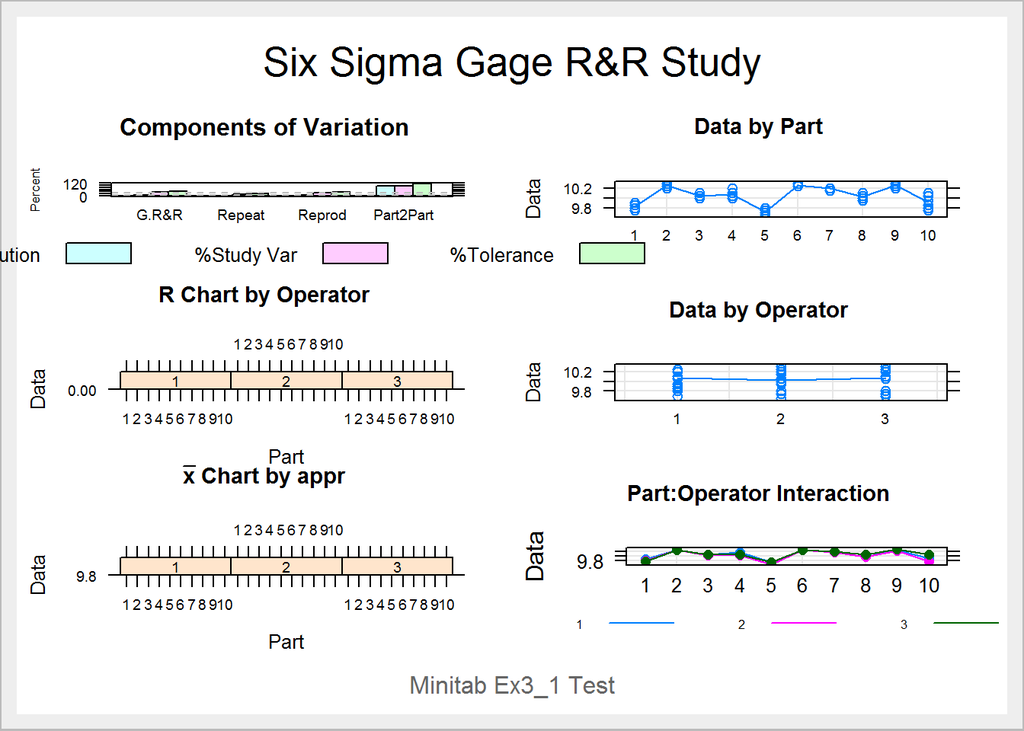